# Benefit Threat to City Solvency

### 2. Unfunded OPEB Liability Per Capita

The difference in the reported UAALs and our own valuations scaled by population size are illustrated in Figure 5 below. We provide per capita measures to present city residents a better idea of their city’s OPEB financial burden and how it compares with that of other cities.

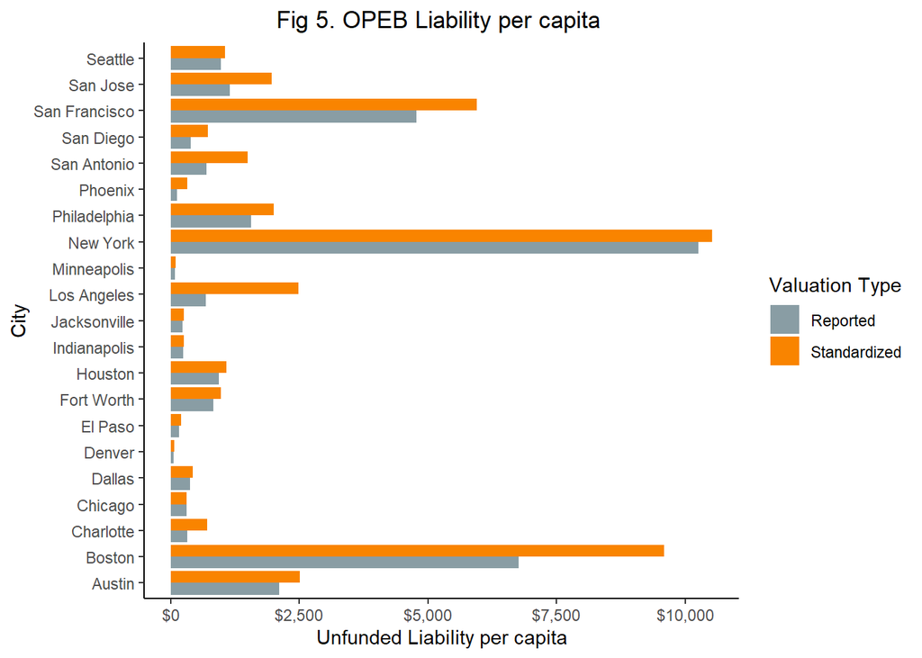

### 3. Share of revenue

The share or proportion of a city’s revenues used to pay for benefit payments in 2017 is illustrated in Figure 6. This further provides users with another alternative to compare cities regarding their OPEB financial burden. The average share of revenue was **2.95%** with a low of **0.16%** for Denver and a high of **7.2%** for Los Angeles. It is interesting to note that the city of New York fares much better under this metric than the previous ones.

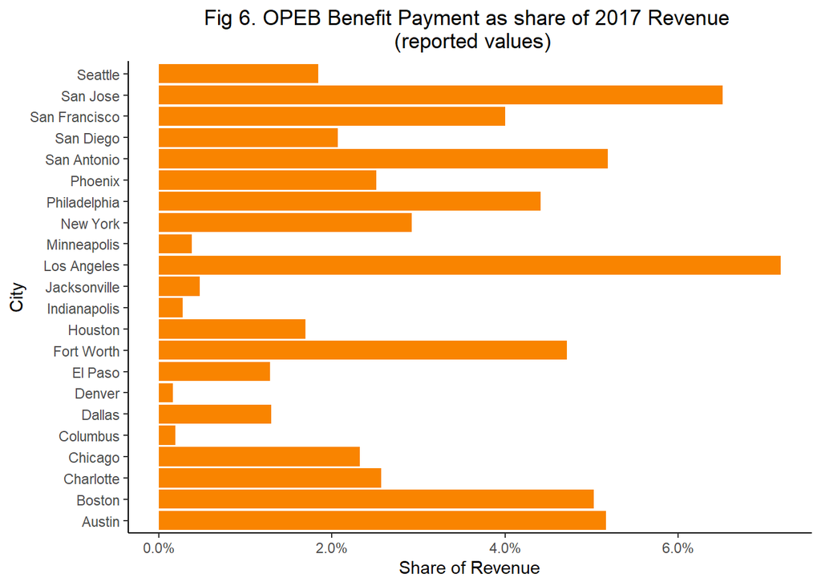